# ML_hw4

박지은

2020 3 13

# Knn 복습문제제

## 문제에 들어가기 전에 먼저 데이터 전처리 하기

```r
# 데이터 읽기

#데이터 파일을 filepath에 저장
filepath <- "https://quantdev.ssri.psu.edu/sites/qdev/files/student-mat.csv"
#url() function을 이용해서 파일 열기
data <- read.table(file=url(filepath),sep=";",header=TRUE)

#모든변수 이름을 소문자로 하기
var.names.data <-tolower(colnames(data))
colnames(data) <- var.names.data
head(data)
```

```
##   school sex age address famsize pstatus medu fedu     mjob     fjob
## 1     GP   F  18       U     GT3       A    4    4  at_home  teacher
## 2     GP   F  17       U     GT3       T    1    1  at_home    other
## 3     GP   F  15       U     LE3       T    1    1  at_home    other
## 4     GP   F  15       U     GT3       T    4    2   health services
## 5     GP   F  16       U     GT3       T    3    3    other    other
## 6     GP   M  16       U     LE3       T    4    3 services    other
##       reason guardian traveltime studytime failures schoolsup famsup paid
## 1     course   mother          2         2        0       yes     no   no
## 2     course   father          1         2        0        no    yes   no
## 3      other   mother          1         2        3       yes     no  yes
## 4       home   mother          1         3        0        no    yes  yes
## 5       home   father          1         2        0        no    yes  yes
## 6 reputation   mother          1         2        0        no    yes  yes
##   activities nursery higher internet romantic famrel freetime goout dalc
## 1         no     yes    yes       no       no      4        3     4    1
## 2         no      no    yes      yes       no      5        3     3    1
## 3         no     yes    yes      yes       no      4        3     2    2
## 4        yes     yes    yes      yes      yes      3        2     2    1
## 5         no     yes    yes       no       no      4        3     2    1
## 6        yes     yes    yes      yes       no      5        4     2    1
##   walc health absences g1 g2 g3
## 1    1      3        6  5  6  6
## 2    1      3        4  5  5  6
## 3    3      3       10  7  8 10
## 4    1      5        2 15 14 15
## 5    2      5        4  6 10 10
## 6    2      5       10 15 15 15
```

```r
#필요한 라이브러리
library(caret)
library(class)
library(dplyr)
library(e1071)
library(FNN)
library(gmodels)
library(psych)
data_class <- data


#mjob을 예측하려 함(그래서 따로 데이터를 빼줌)
mjob_outcome <- data_class %>% select(mjob)

# mjob을 뺀 데이터
#data_class <- data_class %>% select(-mjob)
#str(data_class)

##세 가지 이상의 level 없애기, yes/no factor(level이 numeric인 거) 없애기
##필요한 부분만 쓰기
data_class<-data_class %>% select(age, traveltime, studytime,failures,health,school,sex,address,famsize,mjob)
head(data_class)
```

```
##   age traveltime studytime failures health school sex address famsize
## 1  18          2         2        0      3     GP   F       U     GT3
## 2  17          1         2        0      3     GP   F       U     GT3
## 3  15          1         2        3      3     GP   F       U     LE3
## 4  15          1         3        0      5     GP   F       U     GT3
## 5  16          1         2        0      5     GP   F       U     GT3
## 6  16          1         2        0      5     GP   M       U     LE3
##       mjob
## 1  at_home
## 2  at_home
## 3  at_home
## 4   health
## 5    other
## 6 services
```

```r
str(data_class)
```

```
## 'data.frame':    395 obs. of  10 variables:
##  $ age       : int  18 17 15 15 16 16 16 17 15 15 ...
##  $ traveltime: int  2 1 1 1 1 1 1 2 1 1 ...
##  $ studytime : int  2 2 2 3 2 2 2 2 2 2 ...
##  $ failures  : int  0 0 3 0 0 0 0 0 0 0 ...
##  $ health    : int  3 3 3 5 5 5 3 1 1 5 ...
##  $ school    : Factor w/ 2 levels "GP","MS": 1 1 1 1 1 1 1 1 1 1 ...
##  $ sex       : Factor w/ 2 levels "F","M": 1 1 1 1 1 2 2 1 2 2 ...
##  $ address   : Factor w/ 2 levels "R","U": 2 2 2 2 2 2 2 2 2 2 ...
##  $ famsize   : Factor w/ 2 levels "GT3","LE3": 1 1 2 1 1 2 2 1 2 1 ...
##  $ mjob      : Factor w/ 5 levels "at_home","health",..: 1 1 1 2 3 4 3 3 4 3 ...
```

## 문제 1-1 = data_class를 정규화 시켜주기 - 그리고 더미화도 시켜주기

```r
normalize = function(x){
  return ((x-min(x)) / (max(x)-min(x)))
}
nums = as.data.frame(lapply(select(data_class,-c(school,sex,address,famsize,mjob)),normalize))
head(nums,10)
```

```
##          age traveltime studytime failures health
## 1  0.4285714  0.3333333 0.3333333        0    0.5
## 2  0.2857143  0.0000000 0.3333333        0    0.5
## 3  0.0000000  0.0000000 0.3333333        1    0.5
## 4  0.0000000  0.0000000 0.6666667        0    1.0
## 5  0.1428571  0.0000000 0.3333333        0    1.0
## 6  0.1428571  0.0000000 0.3333333        0    1.0
## 7  0.1428571  0.0000000 0.3333333        0    0.5
## 8  0.2857143  0.3333333 0.3333333        0    0.0
## 9  0.0000000  0.0000000 0.3333333        0    0.0
## 10 0.0000000  0.0000000 0.3333333        0    1.0
```

```r
data_class[,c("age","traveltime","studytime","failures","health")] = nums
head(data_class)
```

```
##         age traveltime studytime failures health school sex address
## 1 0.4285714  0.3333333 0.3333333        0    0.5     GP   F       U
## 2 0.2857143  0.0000000 0.3333333        0    0.5     GP   F       U
## 3 0.0000000  0.0000000 0.3333333        1    0.5     GP   F       U
## 4 0.0000000  0.0000000 0.6666667        0    1.0     GP   F       U
## 5 0.1428571  0.0000000 0.3333333        0    1.0     GP   F       U
## 6 0.1428571  0.0000000 0.3333333        0    1.0     GP   M       U
##   famsize     mjob
## 1     GT3  at_home
## 2     GT3  at_home
## 3     LE3  at_home
## 4     GT3   health
## 5     GT3    other
## 6     LE3 services
```

```r
data_class$school = dummy.code(data_class$school)
data_class$sex = dummy.code(data_class$sex)
data_class$address = dummy.code(data_class$address)
data_class$famsize = dummy.code(data_class$famsize)
str(data_class)
```

```
## 'data.frame':    395 obs. of  10 variables:
##  $ age       : num  0.429 0.286 0 0 0.143 ...
##  $ traveltime: num  0.333 0 0 0 0 ...
##  $ studytime : num  0.333 0.333 0.333 0.667 0.333 ...
##  $ failures  : num  0 0 1 0 0 0 0 0 0 0 ...
##  $ health    : num  0.5 0.5 0.5 1 1 1 0.5 0 0 1 ...
##  $ school    : num [1:395, 1:2] 1 1 1 1 1 1 1 1 1 1 ...
##   ..- attr(*, "dimnames")=List of 2
##   .. ..$ : NULL
##   .. ..$ : chr  "GP" "MS"
##  $ sex       : num [1:395, 1:2] 1 1 1 1 1 0 0 1 0 0 ...
##   ..- attr(*, "dimnames")=List of 2
##   .. ..$ : NULL
##   .. ..$ : chr  "F" "M"
##  $ address   : num [1:395, 1:2] 1 1 1 1 1 1 1 1 1 1 ...
##   ..- attr(*, "dimnames")=List of 2
##   .. ..$ : NULL
##   .. ..$ : chr  "U" "R"
##  $ famsize   : num [1:395, 1:2] 1 1 0 1 1 0 0 1 0 1 ...
##   ..- attr(*, "dimnames")=List of 2
##   .. ..$ : NULL
##   .. ..$ : chr  "GT3" "LE3"
##  $ mjob      : Factor w/ 5 levels "at_home","health",..: 1 1 1 2 3 4 3 3 4 3 ...
```

## 문제 1-2 = 정규화와 dummy화한 데이터를 train, test set나누기(비율은 train:test=7:3)train, test set 나누기 전에 set.seed(1234) 사용하기

```r
set.seed(1234)
train_index = createDataPartition(data_class$mjob, p=0.7, list=F)
data_train = data_class[train_index,]
data_test = data_class[-train_index,]
```

## 문제 1-3 = 모델링을 통해 confusionMatrix 도출하기 (number=10, repeats=2로 지정)

```r
tt = trainControl(method='repeatedcv', number=10, repeats=2)
set.seed(123)
knnFit1 = train(mjob~., data=data_train, method='knn',
                trControl=tt, metric='Accuracy',tuneLength=10)
knnFit1
```

```
## k-Nearest Neighbors
##
## 279 samples
##   9 predictor
##   5 classes: 'at_home', 'health', 'other', 'services', 'teacher'
##
## No pre-processing
## Resampling: Cross-Validated (10 fold, repeated 2 times)
## Summary of sample sizes: 250, 252, 252, 251, 251, 252, ...
## Resampling results across tuning parameters:
##
##   k   Accuracy   Kappa
##    5  0.2640512  -0.003181327
##    7  0.2810770   0.018709049
##    9  0.2719592  -0.015663287
##   11  0.2794943  -0.016147201
##   13  0.2806217  -0.032010316
##   15  0.2786844  -0.034641417
##   17  0.2702849  -0.058430504
##   19  0.2978816  -0.030706753
##   21  0.2928318  -0.040925720
##   23  0.3038029  -0.027281399
##
## Accuracy was used to select the optimal model using the largest value.
## The final value used for the model was k = 23.
```

```r
knnPredict1 = predict(knnFit1, newdata = data_test)
cmat1 = confusionMatrix(knnPredict1, data_test$mjob)
cmat1
```

```
## Confusion Matrix and Statistics
##
##           Reference
## Prediction at_home health other services teacher
##   at_home        0      1     1        1       0
##   health         0      0     0        1       0
##   other         14      8    35       23      14
##   services       3      0     3        5       3
##   teacher        0      1     3        0       0
##
## Overall Statistics
##
##                Accuracy : 0.3448
##                  95% CI : (0.259, 0.4388)
##     No Information Rate : 0.3621
##     P-Value [Acc > NIR] : 0.6829
##
##                   Kappa : 0.016
##
##  Mcnemar's Test P-Value : NA
##
## Statistics by Class:
##
##                      Class: at_home Class: health Class: other
## Sensitivity                 0.00000      0.000000       0.8333
## Specificity                 0.96970      0.990566       0.2027
## Pos Pred Value              0.00000      0.000000       0.3723
## Neg Pred Value              0.84956      0.913043       0.6818
## Prevalence                  0.14655      0.086207       0.3621
## Detection Rate              0.00000      0.000000       0.3017
## Detection Prevalence        0.02586      0.008621       0.8103
## Balanced Accuracy           0.48485      0.495283       0.5180
##                      Class: services Class: teacher
## Sensitivity                   0.1667        0.00000
## Specificity                   0.8953        0.95960
## Pos Pred Value                0.3571        0.00000
## Neg Pred Value                0.7549        0.84821
## Prevalence                    0.2586        0.14655
## Detection Rate                0.0431        0.00000
## Detection Prevalence          0.1207        0.03448
## Balanced Accuracy             0.5310        0.47980
```

# Kmeans 복습문제

```r
## 데이터를 다시 원상복귀하고 이번에는 scale(표준화)를시켜주겠습니다.
data_class <- data
mjob_outcome <- data_class %>% select(mjob)
data_class <- data_class %>% select(-mjob)
data_class<-data_class %>% select(age, traveltime, studytime,failures,health,school,sex,address,famsize)
data_class[, c("age","traveltime",
               "studytime", "failures", "health")] <- scale(data_class[, c("age", "traveltime", "studytime", "failures", "health")])
head(data_class)
```

```
##          age traveltime   studytime   failures     health school sex
## 1  1.0217506  0.7912473 -0.04223229 -0.4493737 -0.3987837     GP   F
## 2  0.2380778 -0.6424347 -0.04223229 -0.4493737 -0.3987837     GP   F
## 3 -1.3292678 -0.6424347 -0.04223229  3.5847768 -0.3987837     GP   F
## 4 -1.3292678 -0.6424347  1.14932149 -0.4493737  1.0397512     GP   F
## 5 -0.5455950 -0.6424347 -0.04223229 -0.4493737  1.0397512     GP   F
## 6 -0.5455950 -0.6424347 -0.04223229 -0.4493737  1.0397512     GP   M
##   address famsize
## 1       U     GT3
## 2       U     GT3
## 3       U     LE3
## 4       U     GT3
## 5       U     GT3
## 6       U     LE3
```

```r
##Kmeans 연속형 처리 –Kmeans 함수에 연속형(수치형) 변수들만을 가져와 돌려보려 합니다. mjob을 기준으로 나누어 보려 합니다. (아직 문제 아님, 문제 소개입니다)
#mjob_outcome 빼주었던 것을 다시 합쳐줌
pre_kmeans<-cbind(data_class,mjob_outcome)
str(pre_kmeans)
```

```
## 'data.frame':    395 obs. of  10 variables:
##  $ age       : num  1.022 0.238 -1.329 -1.329 -0.546 ...
##  $ traveltime: num  0.791 -0.642 -0.642 -0.642 -0.642 ...
##  $ studytime : num  -0.0422 -0.0422 -0.0422 1.1493 -0.0422 ...
##  $ failures  : num  -0.449 -0.449 3.585 -0.449 -0.449 ...
##  $ health    : num  -0.399 -0.399 -0.399 1.04 1.04 ...
##  $ school    : Factor w/ 2 levels "GP","MS": 1 1 1 1 1 1 1 1 1 1 ...
##  $ sex       : Factor w/ 2 levels "F","M": 1 1 1 1 1 2 2 1 2 2 ...
##  $ address   : Factor w/ 2 levels "R","U": 2 2 2 2 2 2 2 2 2 2 ...
##  $ famsize   : Factor w/ 2 levels "GT3","LE3": 1 1 2 1 1 2 2 1 2 1 ...
##  $ mjob      : Factor w/ 5 levels "at_home","health",..: 1 1 1 2 3 4 3 3 4 3 ...
```

```r
#수치형만 변수로 가져와줌
num_data<-pre_kmeans[,-c(6:9)]
head(num_data)
```

```
##          age traveltime   studytime   failures     health     mjob
## 1  1.0217506  0.7912473 -0.04223229 -0.4493737 -0.3987837  at_home
## 2  0.2380778 -0.6424347 -0.04223229 -0.4493737 -0.3987837  at_home
## 3 -1.3292678 -0.6424347 -0.04223229  3.5847768 -0.3987837  at_home
## 4 -1.3292678 -0.6424347  1.14932149 -0.4493737  1.0397512   health
## 5 -0.5455950 -0.6424347 -0.04223229 -0.4493737  1.0397512    other
## 6 -0.5455950 -0.6424347 -0.04223229 -0.4493737  1.0397512 services
```

## 문제 2-1 = 엘보식을 이용하여 그래프를 그려봅니다. 그리고 엘보식으로 구한 k값으로 kmeans 함수를 돌려봅니다. 정확성도 확인해 봅니다.

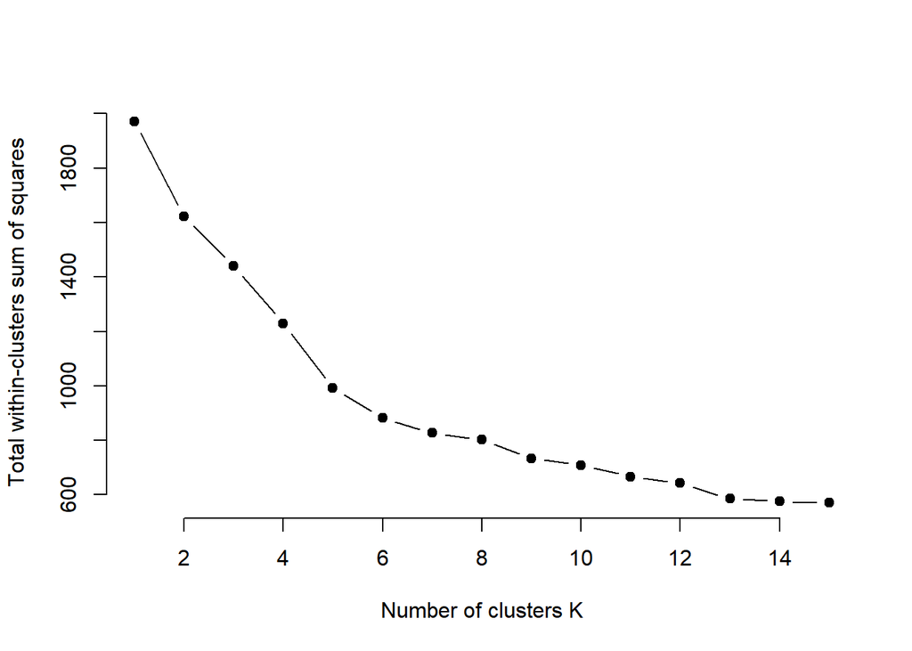

```r
## 엘보식
set.seed(123)
# k = 15까지만 돌려보겠습니다
k_max = 15
wss = sapply(1:k_max,
              function(k){kmeans(num_data[,-6], k, iter.max = 1000 )$tot.withinss})
plot(1:k_max, wss,
     type="b", pch = 19, frame = FALSE,
     xlab="Number of clusters K",
     ylab="Total within-clusters sum of squares")
```

```r
##kmeans 해보기
head(num_data)
```

```
##          age traveltime   studytime   failures     health     mjob
## 1  1.0217506  0.7912473 -0.04223229 -0.4493737 -0.3987837  at_home
## 2  0.2380778 -0.6424347 -0.04223229 -0.4493737 -0.3987837  at_home
## 3 -1.3292678 -0.6424347 -0.04223229  3.5847768 -0.3987837  at_home
## 4 -1.3292678 -0.6424347  1.14932149 -0.4493737  1.0397512   health
## 5 -0.5455950 -0.6424347 -0.04223229 -0.4493737  1.0397512    other
## 6 -0.5455950 -0.6424347 -0.04223229 -0.4493737  1.0397512 services
```

```r
model = kmeans(num_data[,-6],centers=5, iter.max=10000)
model
```

```
## K-means clustering with 5 clusters of sizes 74, 93, 33, 98, 97
##
## Cluster means:
##          age traveltime  studytime   failures     health
## 1  0.4075206  1.3918438 -0.4769884 -0.1949678  0.1358070
## 2  0.4066096 -0.3495319  1.2005711 -0.1601873  0.1812707
## 3  0.4280591  0.3133533 -0.4394169  2.8920439  0.1025239
## 4 -0.6735416 -0.4376230 -0.4434698 -0.3396009  0.8856225
## 5 -0.1658772 -0.3911709 -0.1896410 -0.3384693 -1.2070327
##
## Clustering vector:
##   [1] 1 5 3 4 4 4 5 5 5 4 5 1 4 5 2 5 5 1 3 4 5 4 4 4 4 3 4 5 4 4 4 4 4 5 4
##  [36] 4 2 2 4 5 1 4 4 5 4 4 5 2 4 5 1 4 4 4 5 5 5 4 4 4 4 1 5 2 5 1 2 2 4 2
##  [71] 2 2 3 4 4 4 5 2 3 5 4 4 4 4 4 3 5 5 1 4 2 5 5 5 2 2 1 4 5 2 4 2 4 5 5
## [106] 2 2 2 1 2 4 5 4 4 4 4 5 4 1 4 5 2 4 4 4 4 5 3 3 4 3 1 4 4 1 4 1 3 4 4
## [141] 2 3 4 5 3 4 3 4 4 3 3 4 3 3 4 5 4 3 1 4 3 3 4 5 3 5 4 5 4 5 3 1 4 3 1
## [176] 1 4 4 5 5 5 5 4 5 5 4 5 4 5 5 5 5 1 4 1 4 4 1 1 5 5 4 5 5 2 2 3 5 4 2
## [211] 2 5 4 2 5 5 3 2 1 2 1 2 5 1 2 2 5 5 1 2 5 5 5 5 4 5 4 4 1 5 1 1 5 4 2
## [246] 1 1 3 2 4 1 1 4 1 4 1 2 5 2 2 5 5 2 2 2 5 4 1 2 1 3 2 1 5 5 1 1 1 2 5
## [281] 1 5 2 1 4 4 2 2 2 5 2 2 2 2 2 4 1 1 2 5 2 1 2 2 2 2 1 1 2 2 2 1 2 5 3
## [316] 2 5 2 2 2 4 5 2 2 2 2 4 1 2 2 2 2 2 5 2 2 2 5 2 5 2 5 2 2 2 5 2 2 2 1
## [351] 3 1 5 1 5 2 1 1 1 2 1 1 1 5 1 1 2 1 1 1 3 1 2 5 5 1 3 5 5 5 5 1 1 1 1
## [386] 2 1 2 5 1 3 1 3 1 4
##
## Within cluster sum of squares by cluster:
## [1] 226.3284 252.8867 189.0429 136.8274 185.9127
##  (between_SS / total_SS =  49.7 %)
##
## Available components:
##
## [1] "cluster"      "centers"      "totss"        "withinss"
## [5] "tot.withinss" "betweenss"    "size"         "iter"
## [9] "ifault"
```

```r
##정확성 확인
class(num_data)
```

```
## [1] "data.frame"
```

```r
class(model$cluster)
```

```
## [1] "integer"
```

```r
num_data$train_cluster = as.factor(model$cluster)
table(num_data$mjob, num_data$train_cluster)
```

```
##
##             1  2  3  4  5
##   at_home  17 16  6  4 16
##   health    4  8  2 12  8
##   other    29 30 12 40 30
##   services 15 26 13 26 23
##   teacher   9 13  0 16 20
```

## Kmeans 범주형 –Kmeans 개념을 차용한 kmodes 함수를 사용해 보려 합니다. //factor인 변수들만 가져와주기(mjob을 기준으로 clustering을 해줄 것이기 때문에 factor인 mjob은 포함하지 않음)

```r
##준비
str(pre_kmeans)
```

```
## 'data.frame':    395 obs. of  10 variables:
##  $ age       : num  1.022 0.238 -1.329 -1.329 -0.546 ...
##  $ traveltime: num  0.791 -0.642 -0.642 -0.642 -0.642 ...
##  $ studytime : num  -0.0422 -0.0422 -0.0422 1.1493 -0.0422 ...
##  $ failures  : num  -0.449 -0.449 3.585 -0.449 -0.449 ...
##  $ health    : num  -0.399 -0.399 -0.399 1.04 1.04 ...
##  $ school    : Factor w/ 2 levels "GP","MS": 1 1 1 1 1 1 1 1 1 1 ...
##  $ sex       : Factor w/ 2 levels "F","M": 1 1 1 1 1 2 2 1 2 2 ...
##  $ address   : Factor w/ 2 levels "R","U": 2 2 2 2 2 2 2 2 2 2 ...
##  $ famsize   : Factor w/ 2 levels "GT3","LE3": 1 1 2 1 1 2 2 1 2 1 ...
##  $ mjob      : Factor w/ 5 levels "at_home","health",..: 1 1 1 2 3 4 3 3 4 3 ...
```

```r
fac_data = pre_kmeans[,6:9]
str(fac_data)
```

```
## 'data.frame':    395 obs. of  4 variables:
##  $ school : Factor w/ 2 levels "GP","MS": 1 1 1 1 1 1 1 1 1 1 ...
##  $ sex    : Factor w/ 2 levels "F","M": 1 1 1 1 1 2 2 1 2 2 ...
##  $ address: Factor w/ 2 levels "R","U": 2 2 2 2 2 2 2 2 2 2 ...
##  $ famsize: Factor w/ 2 levels "GT3","LE3": 1 1 2 1 1 2 2 1 2 1 ...
```

## 문제 2-2 = K-modes 함수를 이용해 clustering을 해 봅니다. 그리고 data$mjob과 kmodes 함수를 사용해 나온 cluster를 비교해 정확성을 확인합니다. (kmodes함수 사용 전 set.seed(123)써주기)

```r
set.seed(123)

library(klaR)
cl = kmodes(fac_data,5)
cl
```

```
## K-modes clustering with 5 clusters of sizes 85, 137, 152, 12, 9
##
## Cluster modes:
##   school sex address famsize
## 1     GP   F       R     GT3
## 2     GP   M       U     GT3
## 3     GP   F       U     GT3
## 4     MS   F       U     GT3
## 5     MS   M       U     LE3
##
## Clustering vector:
##   [1] 3 3 3 3 3 2 2 3 2 2 3 3 2 2 2 3 3 3 2 2 2 2 2 2 1 3 2 2 2 2 2 2 1 2 2
##  [36] 3 2 1 1 1 3 2 2 2 3 3 3 2 2 3 3 3 2 3 3 3 3 2 2 3 1 3 3 3 3 3 2 3 1 1
##  [71] 2 2 1 2 3 2 2 3 2 3 2 2 3 2 3 3 3 3 2 2 3 3 3 3 2 1 1 3 3 3 2 2 2 3 2
## [106] 3 3 2 1 3 2 1 3 2 1 2 2 2 1 2 3 2 3 2 3 2 3 3 1 1 1 3 3 3 1 3 1 3 2 3
## [141] 2 2 3 3 2 3 3 3 2 2 2 2 1 2 3 1 1 1 1 2 1 1 2 2 1 2 2 3 3 3 2 2 2 3 3
## [176] 2 3 2 1 2 2 2 3 3 3 2 2 2 3 1 3 3 2 1 2 3 2 1 3 3 3 3 3 1 1 3 3 3 3 1
## [211] 3 2 3 2 1 3 3 2 3 3 1 3 3 2 3 1 3 2 2 3 3 1 2 2 2 2 2 3 1 2 2 1 2 2 3
## [246] 2 2 2 1 2 2 2 2 1 1 2 3 2 2 3 3 2 1 3 3 1 2 1 2 1 3 3 3 1 3 3 1 2 3 2
## [281] 2 2 1 3 3 2 3 3 2 2 2 3 3 1 1 2 3 3 3 2 3 2 3 3 2 3 2 2 1 3 3 3 2 3 3
## [316] 1 3 3 1 3 3 3 1 3 3 2 2 1 3 3 2 1 3 3 1 3 1 3 3 1 3 2 2 3 3 3 1 2 3 1
## [351] 1 2 5 1 1 4 1 4 5 4 1 5 4 4 1 1 5 1 4 1 4 5 4 1 1 1 4 1 4 1 2 1 2 1 1
## [386] 1 1 1 4 4 5 5 1 5 5
##
## Within cluster simple-matching distance by cluster:
## [1] 80 48 38  5  3
##
## Available components:
## [1] "cluster"    "size"       "modes"      "withindiff" "iterations"
## [6] "weighted"
```

```r
fac_data$kmodes_cluster = as.factor(cl$cluster)
table(data$mjob, fac_data$kmodes_cluster)
```

```
##
##             1  2  3  4  5
##   at_home  20  6 27  3  3
##   health    3 14 16  1  0
##   other    34 45 57  3  2
##   services 17 40 39  4  3
##   teacher  11 32 13  1  1
```